# Exploring Two Variables

```r
library(ggplot2)
library(dplyr)
data(diamonds)
```

Note: Your first task is to create a scatterplot of price vs x. using the ggplot syntax.

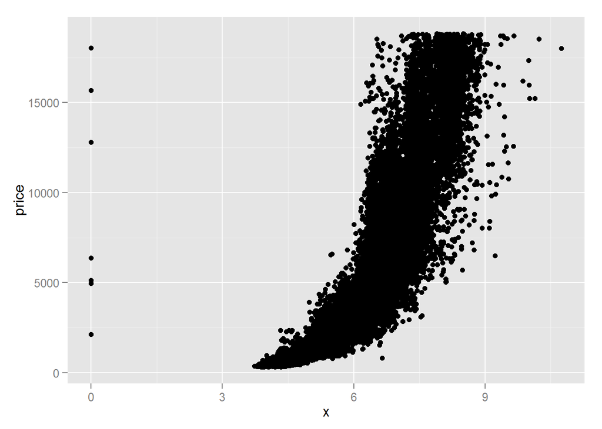

Note: Find correlations of price and x, price and y, price and z

```
##
##  Pearson's product-moment correlation
##
## data:  price and x
## t = 440.1594, df = 53938, p-value < 2.2e-16
## alternative hypothesis: true correlation is not equal to 0
## 95 percent confidence interval:
##  0.8825835 0.8862594
## sample estimates:
##       cor
## 0.8844352
```

```
##
##  Pearson's product-moment correlation
##
## data:  price and y
## t = 401.1415, df = 53938, p-value < 2.2e-16
## alternative hypothesis: true correlation is not equal to 0
## 95 percent confidence interval:
##  0.8632867 0.8675241
## sample estimates:
##       cor
## 0.8654209
```

```
##
##  Pearson's product-moment correlation
##
## data:  price and z
## t = 393.6015, df = 53938, p-value < 2.2e-16
## alternative hypothesis: true correlation is not equal to 0
## 95 percent confidence interval:
##  0.8590541 0.8634131
## sample estimates:
##       cor
## 0.8612494
```

Note: Create a scatterplot of price versus depth.

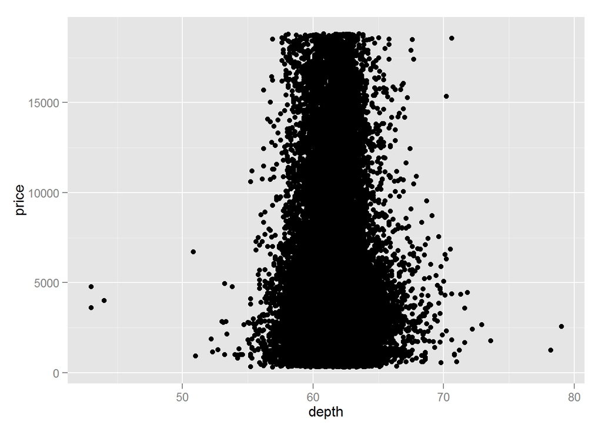

Note: Change the code to make the transparency of the points to be 1/100 of what they are now and mark the x-axis every 2 units.

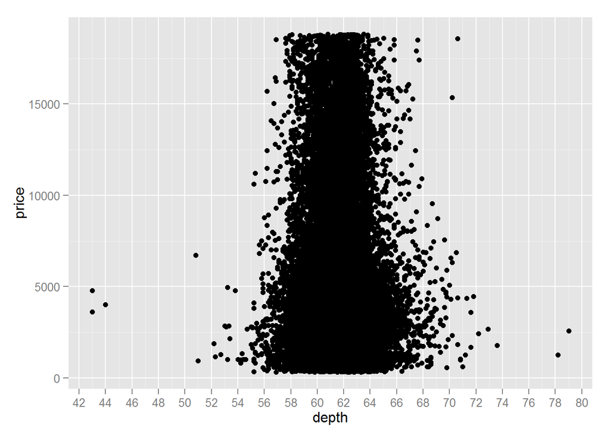

##### Most points are from 58 and 64.

Note: What’s correlation of depth vs price?

```
##
##  Pearson's product-moment correlation
##
## data:  price and depth
## t = -2.473, df = 53938, p-value = 0.0134
## alternative hypothesis: true correlation is not equal to 0
## 95 percent confidence interval:
##  -0.019084756 -0.002208537
## sample estimates:
##        cor
## -0.0106474
```

##### Based on the correlation coefficient would you use depth to predict the price of a diamond?

##### No. Cause the there is no correlation.

Note: Create a scatterplot of price vs carat

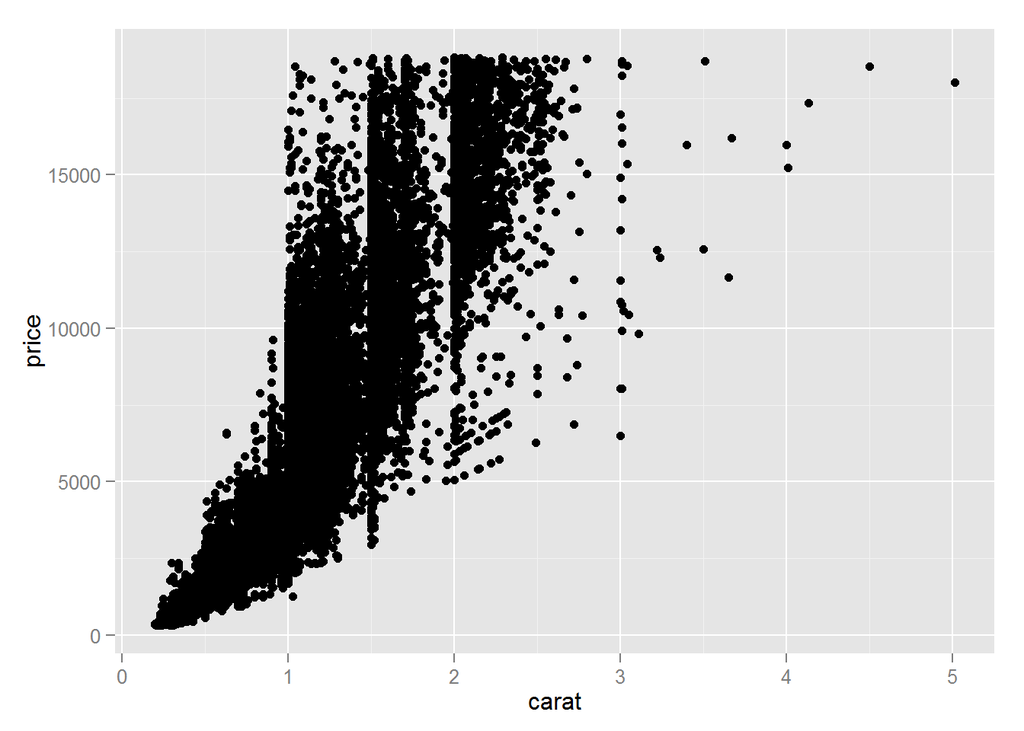

Note: Create a scatterplot of price vs. volume (x * y * z). This is a very rough approximation for a diamond’s volume. Create a new variable for volume in the diamonds data frame.

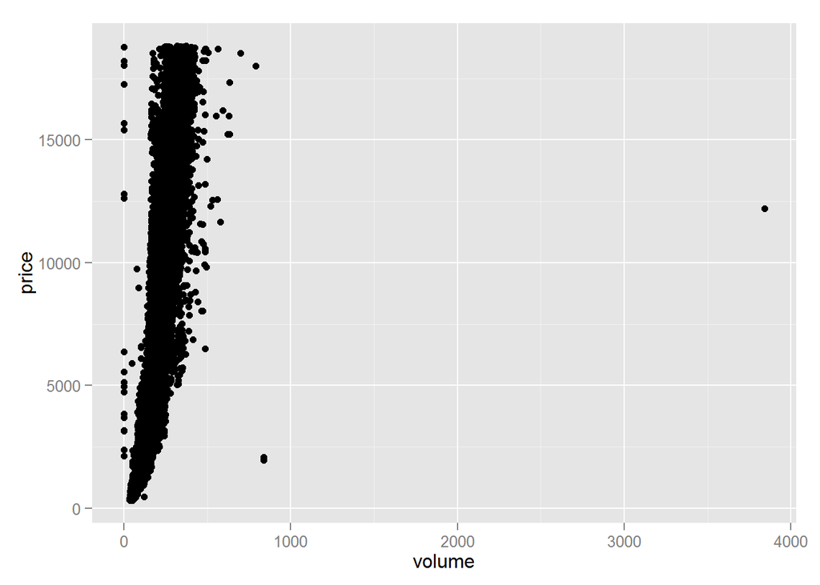

Look at the outliers!

Note: What’s the correlation between price and volume? Exclude diamonds that have a volume of 0 or that are greater or equal to 800.

```
##
##  Pearson's product-moment correlation
##
## data:  volume and price
## t = 559.1912, df = 53915, p-value < 2.2e-16
## alternative hypothesis: true correlation is not equal to 0
## 95 percent confidence interval:
##  0.9222944 0.9247772
## sample estimates:
##       cor
## 0.9235455
```

Note: Subset the data to exclude diamonds with a volume greater than or equal to 800. Also, exclude diamonds with a volume of 0. Adjust the transparency of the points and add a linear model to the plot. Do you think this would be a useful mode to estimate the price of diamonds? Why or why not?

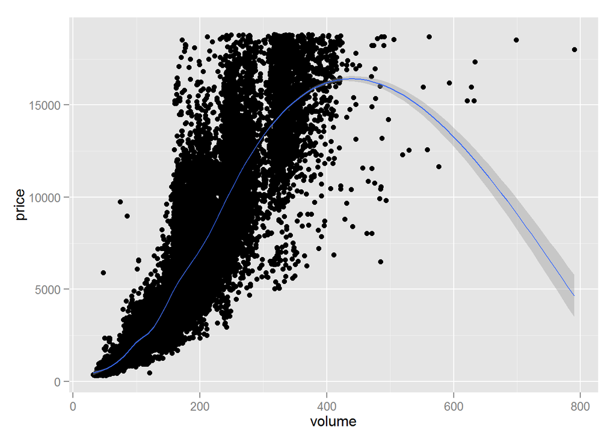

##### For volume <= 400, it seems it’a a good fit. But after that, it seems weired.

Use the function dplyr package to create a new data frame containing info on diamonds by clarity. Name the data frame diamondsByClarity

The data frame should contain the following variables in this order. (1) mean_price (2) median_price (3) min_price (4) max_price (5) n

where n is the number of diamonds in each level of clarity.

```
## Source: local data frame [6 x 6]
##
##   clarity mean_price median_price min_price max_price     n
##    (fctr)      (dbl)        (dbl)     (int)     (int) (int)
## 1      I1   3924.169         3344       345     18531   741
## 2     SI2   5063.029         4072       326     18804  9194
## 3     SI1   3996.001         2822       326     18818 13065
## 4     VS2   3924.989         2054       334     18823 12258
## 5     VS1   3839.455         2005       327     18795  8171
## 6    VVS2   3283.737         1311       336     18768  5066
```

Note: We’ve created summary data frames with the mean price by clarity and color.

Your task is to write additional code to create two bar plots on one output image using the grid.arrange() function from the package gridExtra.

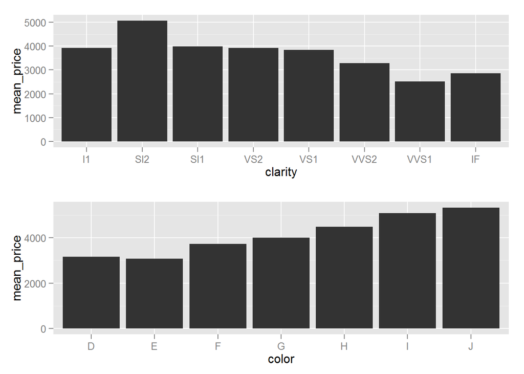